# 6. Analysis of longitudinal data

In the last task, we can fit a random intercept and slope model that allows for a treatment × week interaction.

First I would like to see if there is a interaction between variables treatment and week. I can do that with a simple linear regression model and anova test.

```r
int_test <- lm(bprs ~ week + treatment + week*treatment, data = BPRSL)
anova(int_test)
```

```
## Analysis of Variance Table
##
## Response: bprs
##                 Df Sum Sq Mean Sq F value Pr(>F)
## week             1  12372 12371.5 81.1447 <2e-16 ***
## treatment        1     29    29.5  0.1933 0.6605
## week:treatment   1    307   307.5  2.0166 0.1565
## Residuals      356  54277   152.5
## ---
## Signif. codes:  0 '***' 0.001 '**' 0.01 '*' 0.05 '.' 0.1 ' ' 1
```

From the Analysis of Variance Table above we can see that week is statistically significant variable(p-value small, <2e-16), treatment is not significant variable (p-value 0.66 > 0.05) and there is no interaction between variables week and treatment (p-value 0.16 > 0.05).

Even though we saw that there is no interaction, I can still fit a random intercept and slope modeland see how it looks.

```r
# creating a random intercept and random slope model
BPRSL_ref2 <- lmer(bprs ~ week * treatment + (week | subject), data = BPRSL, REML = FALSE)
summary(BPRSL_ref2)
```

```
## Linear mixed model fit by maximum likelihood  ['lmerMod']
## Formula: bprs ~ week * treatment + (week | subject)
##    Data: BPRSL
##
##      AIC      BIC   logLik deviance df.resid
##   2744.3   2775.4  -1364.1   2728.3      352
##
## Scaled residuals:
##     Min      1Q  Median      3Q     Max
## -3.0512 -0.6271 -0.0768  0.5288  3.9260
##
## Random effects:
##  Groups   Name        Variance Std.Dev. Corr
##  subject  (Intercept) 64.9964  8.0620
##           week         0.9687  0.9842   -0.51
##  Residual             96.4707  9.8220
## Number of obs: 360, groups:  subject, 20
##
## Fixed effects:
##                 Estimate Std. Error t value
## (Intercept)      47.8856     2.2521  21.262
## week             -2.6283     0.3589  -7.323
## treatment2       -2.2911     1.9090  -1.200
## week:treatment2   0.7158     0.4010   1.785
##
## Correlation of Fixed Effects:
##             (Intr) week   trtmn2
## week        -0.650
## treatment2  -0.424  0.469
## wek:trtmnt2  0.356 -0.559 -0.840
```

Then we can compare the models again(BPRSL_ref1 and BPRSL_ref2)

```r
# performing an ANOVA test on the two models
anova(BPRSL_ref2, BPRSL_ref1)
```

```
## Data: BPRSL
## Models:
## BPRSL_ref1: bprs ~ week + treatment + (week | subject)
## BPRSL_ref2: bprs ~ week * treatment + (week | subject)
##            npar    AIC    BIC  logLik deviance  Chisq Df Pr(>Chisq)
## BPRSL_ref1    7 2745.4 2772.6 -1365.7   2731.4
## BPRSL_ref2    8 2744.3 2775.4 -1364.1   2728.3 3.1712  1    0.07495 .
## ---
## Signif. codes:  0 '***' 0.001 '**' 0.01 '*' 0.05 '.' 0.1 ' ' 1
```

Now we can see from the summary that p-value is 0.075 > 0.05, which means that there is no statistically significant difference between the two models, because there was no interaction between week and treatment.

Let´s draw a plot of BPRS again

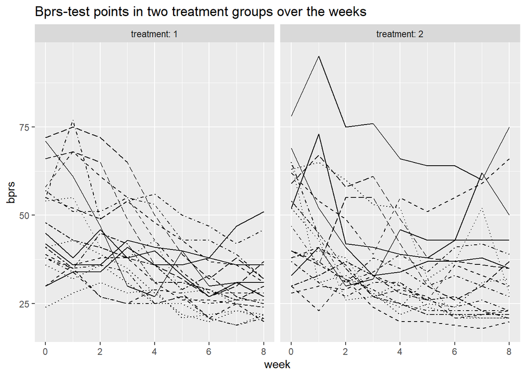

```r
ggplot(BPRSL, aes(x = week, y = bprs, linetype = subject)) +
  geom_line() +
  scale_linetype_manual(values = rep(1:10, times=4)) +
  facet_grid(. ~ treatment, labeller = label_both) +
  theme(legend.position = "none") +
  scale_y_continuous(limits = c(min(BPRSL$bprs), max(BPRSL$bprs)))+
  ggtitle("Bprs-test points in two treatment groups over the weeks")
```

Then I can create a vector of fitted values and add it to the BPRSL data

```r
# Create a vector of the fitted values
Fitted <- fitted(BPRSL_ref2)

# Creating a new column fitted to BPRSL
BPRSL <- BPRSL %>%
  mutate(Fitted)
```

Let´s draw the plot again with fitted values

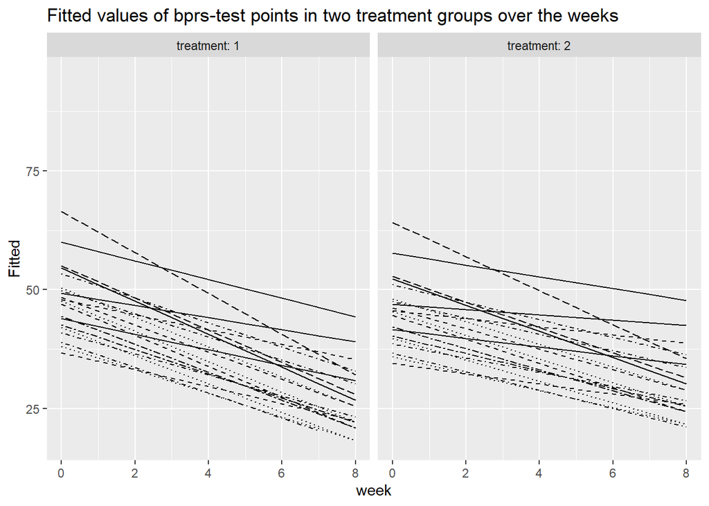

```r
ggplot(BPRSL, aes(x = week, y = Fitted, linetype = subject)) +
  geom_line() +
  scale_linetype_manual(values = rep(1:10, times=4)) +
  facet_grid(. ~ treatment, labeller = label_both) +
  theme(legend.position = "none") +
  scale_y_continuous(limits = c(min(BPRSL$bprs), max(BPRSL$bprs)))+
  ggtitle("Fitted values of bprs-test points in two treatment groups over the weeks")
```

If we compare the two pictures, we can see that the original values and fitted values decrease over the weeks but there is no clear difference between two treatments groups. However, there are differences between plots and the model could be better, for example that one outlier in group 2 is not separated in fitted value plot anymore.